# titanic

###### Questions on titanic data. 1) What would be the surviving factors on titanic. Does age,passenger class,Sex,fare can be the important factors for the survival.Lets analyse the titanic data to find out more.

```python
import pandas as pd
import numpy as np
import matplotlib.pyplot as plt
```

```python
df = pd.read_csv("/Users/praveen/Downloads/titanic_data.csv")
#Reading the dataset in a dataframe using Pandas
```

```python
df.dtypes
```

```
PassengerId      int64
Survived         int64
Pclass           int64
Name            object
Sex             object
Age            float64
SibSp            int64
Parch            int64
Ticket          object
Fare           float64
Cabin           object
Embarked        object
dtype: object
```

```python
print df.head(10)
```

```
   PassengerId  Survived  Pclass  \
0            1         0       3
1            2         1       1
2            3         1       3
3            4         1       1
4            5         0       3
5            6         0       3
6            7         0       1
7            8         0       3
8            9         1       3
9           10         1       2

                                                Name     Sex   Age  SibSp  \
0                            Braund, Mr. Owen Harris    male  22.0      1
1  Cumings, Mrs. John Bradley (Florence Briggs Th...  female  38.0      1
```

[output cut: 20 more lines]

###### Data Cleaning.Lets find out if all the data needed for our analysis are present and check if the values are appropriate.

```python
df['Age'].count()
```

```
714
```

```python
df['PassengerId'].count()
```

```
891
```

```python
df['Survived'].count()
```

```
891
```

```python
df['Sex'].count()
```

```
891
```

```python
df['Pclass'].count()
```

```
891
```

```python
df['Pclass'].unique()

### So teher are 3 different class of passengers.
```

```
array([3, 1, 2])
```

```python
df['Sex'].unique()
```

```
array(['male', 'female'], dtype=object)
```

```python
#Notice the count of 714 is less than the total row count of  data set 891.
#There are missing data.To find the missing data
missing_age = np.where(df["Age"].isnull() == True)

print len(missing_age[0])
```

```
177
```

```python
print missing_age
```

```
(array([  5,  17,  19,  26,  28,  29,  31,  32,  36,  42,  45,  46,  47,
        48,  55,  64,  65,  76,  77,  82,  87,  95, 101, 107, 109, 121,
       126, 128, 140, 154, 158, 159, 166, 168, 176, 180, 181, 185, 186,
       196, 198, 201, 214, 223, 229, 235, 240, 241, 250, 256, 260, 264,
       270, 274, 277, 284, 295, 298, 300, 301, 303, 304, 306, 324, 330,
       334, 335, 347, 351, 354, 358, 359, 364, 367, 368, 375, 384, 388,
       409, 410, 411, 413, 415, 420, 425, 428, 431, 444, 451, 454, 457,
       459, 464, 466, 468, 470, 475, 481, 485, 490, 495, 497, 502, 507,
       511, 517, 522, 524, 527, 531, 533, 538, 547, 552, 557, 560, 563,
       564, 568, 573, 578, 584, 589, 593, 596, 598, 601, 602, 611, 612,
       613, 629, 633, 639, 643, 648, 650, 653, 656, 667, 669, 674, 680,
       692, 697, 709, 711, 718, 727, 732, 738, 739, 740, 760, 766, 768,
       773, 776, 778, 783, 790, 792, 793, 815, 825, 826, 828, 832, 837,
       839, 846, 849, 859, 863, 868, 878, 888]),)
```

```python
age_isnumber=df[df['Age']>=0]
print len(age_isnumber)
```

```
714
```

```python
not_survived=df[df['Survived']==0]
print len(not_survived)
```

```
549
```

```python
#Total not survived is 549
survived=df[df['Survived']==1]
print len(survived)

##### we have all the 891 data for survived list
```

```
342
```

```
array([[<matplotlib.axes._subplots.AxesSubplot object at 0x1151d3710>]], dtype=object)
```

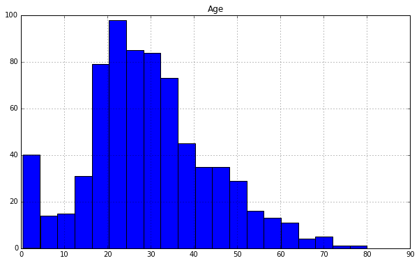

```python
%pylab inline
df.hist(column='Age',    # Column to plot
                   figsize=(10,6),   # Plot size
                   bins=20)         # Number of histogram bins
```

###### The ages has 177 values which is too huge to drop hence we can use interpolate() function to add values by interpolation.We want the ages to be in ineteger rather than float values which makes convient to use so we can convert the datatype as integer.

```python
df['filled_ages'] = df['Age'].interpolate()

df['filled_ages']=df['filled_ages'].astype(int)
df['filled_ages'],df['Age']
```

```
(0      22
 1      38
 2      26
 3      35
 4      35
 5      44
 6      54
 7       2
 8      27
 9      14
 10      4
 11     58
 12     20
 13     39
 14     14
```

[output cut: 108 more lines]